# Summary of JAGS model

## Posterior Summary

|  | Lower95 | Median | Upper95 | Mean | SD | Mode | MCerr | MC%ofSD | SSeff | AC.10000 | psrf |
| --- | --- | --- | --- | --- | --- | --- | --- | --- | --- | --- | --- |
| **deviance** | 44512 | 44564 | 44616 | 44564 | 26.62 | 44564 | 0.1213 | 0.5 | 48187 | 0.002962 | 1 |
| **sire.vcov[1,1]** | 0.0004497 | 3.125 | 8.544 | 3.662 | 2.62 | 2.403 | 0.01194 | 0.5 | 48173 | 0.004715 | 1 |
| **sire.vcov[2,1]** | -6.06 | 0.6912 | 9.014 | 0.9672 | 3.715 | 0.3705 | 0.01671 | 0.4 | 49423 | -0.00209 | 1 |
| **sire.vcov[3,1]** | -0.2268 | 0.398 | 1.383 | 0.4701 | 0.433 | 0.2868 | 0.001973 | 0.5 | 48145 | -0.003905 | 1 |
| **sire.vcov[4,1]** | -0.9671 | -0.04503 | 0.7621 | -0.06146 | 0.4196 | -0.04598 | 0.001879 | 0.4 | 49893 | 0.007459 | 1 |
| **sire.vcov[1,2]** | -6.06 | 0.6912 | 9.014 | 0.9672 | 3.715 | 0.3705 | 0.01671 | 0.4 | 49423 | -0.00209 | 1 |
| **sire.vcov[2,2]** | 0.2469 | 26.33 | 60.95 | 29.29 | 16.99 | 23.06 | 0.07756 | 0.5 | 47998 | -0.005041 | 0.9999 |
| **sire.vcov[3,2]** | -1.662 | 0.2107 | 2.343 | 0.2707 | 0.9792 | 0.1474 | 0.004466 | 0.5 | 48068 | -0.003402 | 0.9999 |
| **sire.vcov[4,2]** | -1.713 | 0.3149 | 2.441 | 0.3721 | 1.019 | 0.2289 | 0.004585 | 0.5 | 49364 | -0.002696 | 1 |
| **sire.vcov[1,3]** | -0.2268 | 0.398 | 1.383 | 0.4701 | 0.433 | 0.2868 | 0.001973 | 0.5 | 48145 | -0.003905 | 1 |
| **sire.vcov[2,3]** | -1.662 | 0.2107 | 2.343 | 0.2707 | 0.9792 | 0.1474 | 0.004466 | 0.5 | 48068 | -0.003402 | 0.9999 |
| **sire.vcov[3,3]** | 0.0001082 | 0.227 | 0.6453 | 0.2701 | 0.2 | 0.1643 | 0.0009211 | 0.5 | 47154 | -0.004654 | 1 |
| **sire.vcov[4,3]** | -0.1923 | 0.0171 | 0.264 | 0.02609 | 0.1114 | 0.01212 | 0.0004986 | 0.4 | 49956 | -0.002249 | 1 |
| **sire.vcov[1,4]** | -0.9671 | -0.04503 | 0.7621 | -0.06146 | 0.4196 | -0.04598 | 0.001879 | 0.4 | 49893 | 0.007459 | 1 |
| **sire.vcov[2,4]** | -1.713 | 0.3149 | 2.441 | 0.3721 | 1.019 | 0.2289 | 0.004585 | 0.5 | 49364 | -0.002696 | 1 |
| **sire.vcov[3,4]** | -0.1923 | 0.0171 | 0.264 | 0.02609 | 0.1114 | 0.01212 | 0.0004986 | 0.4 | 49956 | -0.002249 | 1 |
| **sire.vcov[4,4]** | 0.000009175 | 0.2405 | 0.699 | 0.2891 | 0.2201 | 0.1816 | 0.001013 | 0.5 | 47271 | 0.0009054 | 1 |
| **dam.vcov[1,1]** | 10.9 | 25.33 | 48.04 | 27.27 | 10.39 | 22.98 | 0.04685 | 0.5 | 49229 | 0.002321 | 1 |
| **dam.vcov[2,1]** | -7.624 | 24.2 | 64.2 | 26.27 | 18.42 | 20.82 | 0.08251 | 0.4 | 49819 | -0.005594 | 1 |
| **dam.vcov[3,1]** | -0.4639 | 1.479 | 4.008 | 1.604 | 1.137 | 1.354 | 0.005098 | 0.4 | 49778 | -0.004778 | 1 |
| **dam.vcov[4,1]** | -1.422 | 0.4738 | 2.692 | 0.5356 | 1.03 | 0.4111 | 0.004633 | 0.4 | 49453 | 0.0005997 | 1 |
| **dam.vcov[1,2]** | -7.624 | 24.2 | 64.2 | 26.27 | 18.42 | 20.82 | 0.08251 | 0.4 | 49819 | -0.005594 | 1 |
| **dam.vcov[2,2]** | 82.95 | 177.7 | 325.7 | 190.1 | 68.36 | 161.1 | 0.3076 | 0.5 | 49376 | -0.004408 | 1 |
| **dam.vcov[3,2]** | -1.14 | 4.001 | 10.53 | 4.336 | 2.991 | 3.596 | 0.01339 | 0.4 | 49945 | -0.006626 | 1 |
| **dam.vcov[4,2]** | -7.359 | -2.141 | 2.26 | -2.345 | 2.427 | -1.944 | 0.01089 | 0.4 | 49651 | 0.001284 | 1 |
| **dam.vcov[1,3]** | -0.4639 | 1.479 | 4.008 | 1.604 | 1.137 | 1.354 | 0.005098 | 0.4 | 49778 | -0.004778 | 1 |
| **dam.vcov[2,3]** | -1.14 | 4.001 | 10.53 | 4.336 | 2.991 | 3.596 | 0.01339 | 0.4 | 49945 | -0.006626 | 1 |
| **dam.vcov[3,3]** | 0.09901 | 0.5095 | 1.183 | 0.5677 | 0.3058 | 0.4389 | 0.001387 | 0.5 | 48626 | 0.008618 | 1 |
| **dam.vcov[4,3]** | -0.5185 | -0.1622 | 0.1107 | -0.1802 | 0.161 | -0.1471 | 0.0007267 | 0.5 | 49093 | 0.0006975 | 1 |
| **dam.vcov[1,4]** | -1.422 | 0.4738 | 2.692 | 0.5356 | 1.03 | 0.4111 | 0.004633 | 0.4 | 49453 | 0.0005997 | 1 |

[output cut: 97 more lines]

## V<sub>A</sub>

Latent scale

| metric | lower.hdi | median | mode | upper.hdi | pr.lt.hdi | pr.gt.hdi | 5pc.exceeds | pct.gt.0 |
| --- | --- | --- | --- | --- | --- | --- | --- | --- |
| Var(Trunk) | 0.001799 | 12.5 | 9.659 | 34.17 | 0 | 0.04998 | 34.17 | 1 |
| Var(Tail) | 0.9875 | 105.3 | 92.93 | 243.8 | 0.00054 | 0.04944 | 243.2 | 1 |
| Var(Hatch) | 0.000433 | 0.908 | 0.6581 | 2.581 | 0 | 0.04998 | 2.581 | 1 |
| Var(Settle\|Hatch) | 0.0000367 | 0.9618 | 0.7313 | 2.796 | 0 | 0.04998 | 2.796 | 1 |
| Cov(Trunk, Tail) | -24.24 | 2.765 | 1.487 | 36.05 | 0.0231 | 0.02688 | 29.25 | 0.5973 |
| Cov(Trunk, Hatch) | -0.907 | 1.592 | 1.153 | 5.534 | 0.0145 | 0.03548 | 5.075 | 0.9124 |
| Cov(Trunk, Settle\|Hatch) | -3.868 | -0.1801 | -0.205 | 3.048 | 0.0243 | 0.02568 | 2.343 | 0.436 |
| Cov(Tail, Hatch) | -6.65 | 0.8429 | 0.6128 | 9.371 | 0.02328 | 0.0267 | 7.64 | 0.6153 |
| Cov(Tail, Settle\|Hatch) | -6.851 | 1.26 | 0.8982 | 9.764 | 0.01956 | 0.03042 | 8.254 | 0.6598 |
| Cov(Hatch, Settle\|Hatch) | -0.769 | 0.0684 | 0.05395 | 1.056 | 0.02148 | 0.0285 | 0.8584 | 0.5915 |

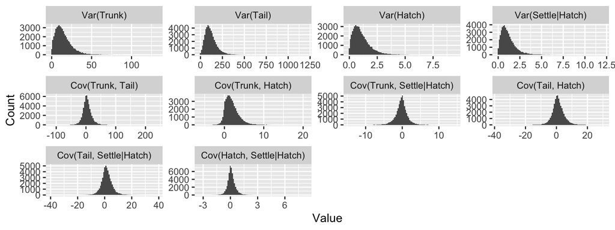

## V<sub>M</sub>

Latent scale

| metric | lower.hdi | median | mode | upper.hdi | pr.lt.hdi | pr.gt.hdi | 5pc.exceeds | pct.gt.0 |
| --- | --- | --- | --- | --- | --- | --- | --- | --- |
| Var(Trunk) | 6.013 | 21.82 | 20.05 | 45.64 | 0.01164 | 0.03834 | 43.42 | 0.9989 |
| Var(Tail) | 45.09 | 149.5 | 135.6 | 301.9 | 0.0105 | 0.03948 | 288.6 | 0.9993 |
| Var(Hatch) | -0.3706 | 0.2696 | 0.2384 | 1.038 | 0.02 | 0.02998 | 0.9027 | 0.8376 |
| Var(Settle\|Hatch) | -0.5152 | 0.1008 | 0.09742 | 0.7747 | 0.02594 | 0.02404 | 0.6151 | 0.6666 |
| Cov(Trunk, Tail) | -10.15 | 23.22 | 21.66 | 63.65 | 0.015 | 0.03498 | 58.48 | 0.9421 |
| Cov(Trunk, Hatch) | -1.1 | 1.034 | 0.9214 | 3.665 | 0.02008 | 0.0299 | 3.248 | 0.8512 |
| Cov(Trunk, Settle\|Hatch) | -1.559 | 0.5443 | 0.4934 | 2.86 | 0.02118 | 0.0288 | 2.453 | 0.7198 |
| Cov(Tail, Hatch) | -1.677 | 3.774 | 3.506 | 10.65 | 0.01878 | 0.0312 | 9.588 | 0.9299 |
| Cov(Tail, Settle\|Hatch) | -8.204 | -2.528 | -2.322 | 2.168 | 0.02802 | 0.02196 | 1.14 | 0.1234 |
| Cov(Hatch, Settle\|Hatch) | -0.6089 | -0.1901 | -0.1668 | 0.1564 | 0.031 | 0.01898 | 0.07644 | 0.1163 |

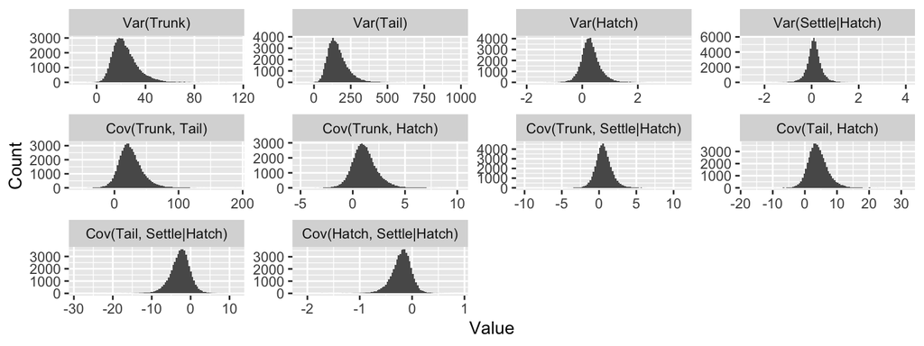

## V<sub>D</sub>

Latent scale

| metric | lower.hdi | median | mode | upper.hdi | pr.lt.hdi | pr.gt.hdi | 5pc.exceeds | pct.gt.0 |
| --- | --- | --- | --- | --- | --- | --- | --- | --- |
| Var(Trunk) | 0.002492 | 9.243 | 5.312 | 26.33 | 0.00004 | 0.04994 | 26.33 | 1 |
| Var(Tail) | 0.2292 | 72.65 | 60.59 | 166.5 | 0.00024 | 0.04974 | 166.4 | 1 |
| Var(Hatch) | 0.04081 | 0.9976 | 0.8708 | 2.278 | 0.00326 | 0.04672 | 2.251 | 1 |
| Var(Settle\|Hatch) | 0.5401 | 1.355 | 1.242 | 2.515 | 0.0085 | 0.04148 | 2.441 | 1 |
| Cov(Trunk, Tail) | -11.97 | 6.297 | 3.659 | 33.9 | 0.01686 | 0.03312 | 30.24 | 0.7586 |
| Cov(Trunk, Hatch) | -3.185 | -0.4352 | -0.4489 | 2.09 | 0.02068 | 0.0293 | 1.634 | 0.3315 |
| Cov(Trunk, Settle\|Hatch) | -3.227 | -0.4393 | -0.3811 | 1.974 | 0.0232 | 0.02678 | 1.534 | 0.341 |
| Cov(Tail, Hatch) | -4.791 | 1.3 | 1.071 | 7.902 | 0.01888 | 0.0311 | 6.945 | 0.6883 |
| Cov(Tail, Settle\|Hatch) | -7.322 | -1.105 | -0.9671 | 4.736 | 0.0253 | 0.02468 | 3.614 | 0.3373 |
| Cov(Hatch, Settle\|Hatch) | -0.4672 | 0.2242 | 0.1978 | 0.9181 | 0.02352 | 0.02646 | 0.7985 | 0.7633 |

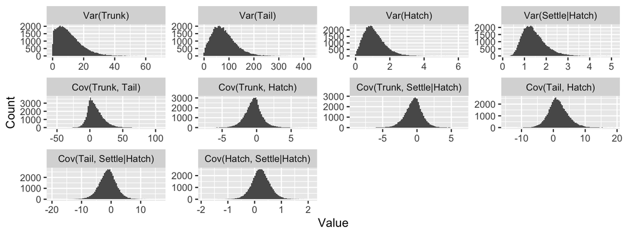

## V<sub>R</sub>

Latent scale

| metric | lower.hdi | median | mode | upper.hdi | pr.lt.hdi | pr.gt.hdi | 5pc.exceeds | pct.gt.0 |
| --- | --- | --- | --- | --- | --- | --- | --- | --- |
| Var(Trunk) | 81.85 | 89.07 | 88.89 | 96.95 | 0.02452 | 0.02546 | 95.73 | 1 |
| Var(Tail) | 301.1 | 329.2 | 328.8 | 357.5 | 0.0186 | 0.03138 | 354.1 | 1 |
| Var(Hatch) | 0 | 0 | 0 | 0 | 0 | 0 | 0 | 0 |
| Var(Settle\|Hatch) | 0 | 0 | 0 | 0 | 0 | 0 | 0 | 0 |
| Cov(Trunk, Tail) | 40.65 | 51.09 | 50.62 | 62.16 | 0.02542 | 0.02456 | 60.38 | 1 |
| Cov(Trunk, Hatch) | 0 | 0 | 0 | 0 | 0 | 0 | 0 | 0 |
| Cov(Trunk, Settle\|Hatch) | 0 | 0 | 0 | 0 | 0 | 0 | 0 | 0 |
| Cov(Tail, Hatch) | 0 | 0 | 0 | 0 | 0 | 0 | 0 | 0 |
| Cov(Tail, Settle\|Hatch) | 0 | 0 | 0 | 0 | 0 | 0 | 0 | 0 |
| Cov(Hatch, Settle\|Hatch) | 0 | 0 | 0 | 0 | 0 | 0 | 0 | 0 |

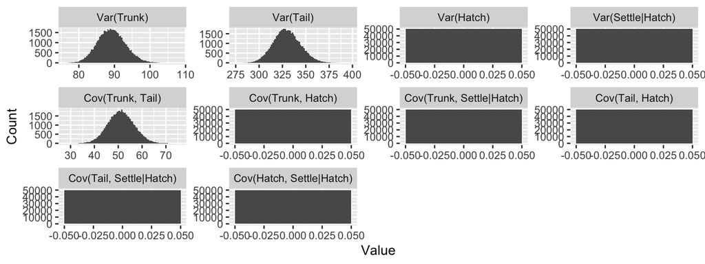

## V<sub>P</sub>

Latent scale

| metric | lower.hdi | median | mode | upper.hdi | pr.lt.hdi | pr.gt.hdi | 5pc.exceeds | pct.gt.0 |
| --- | --- | --- | --- | --- | --- | --- | --- | --- |
| Var(Trunk) | 103.3 | 121.2 | 119.2 | 145.2 | 0.00986 | 0.04012 | 143.4 | 1 |
| Var(Tail) | 450.3 | 557.6 | 545.5 | 710 | 0.00872 | 0.04126 | 699.4 | 1 |
| Var(Hatch) | 0.5111 | 1.05 | 0.9809 | 1.836 | 0.00802 | 0.04196 | 1.784 | 1 |
| Var(Settle\|Hatch) | 0.5185 | 0.9855 | 0.8952 | 1.71 | 0.0079 | 0.04208 | 1.664 | 1 |
| Cov(Trunk, Tail) | 45.1 | 78.57 | 75.95 | 120.8 | 0.0177 | 0.03228 | 114.8 | 1 |
| Cov(Trunk, Hatch) | -0.2344 | 1.836 | 1.712 | 4.556 | 0.01964 | 0.03034 | 4.131 | 0.9686 |
| Cov(Trunk, Settle\|Hatch) | -1.866 | 0.3069 | 0.2145 | 2.627 | 0.02144 | 0.02854 | 2.24 | 0.6247 |
| Cov(Tail, Hatch) | -0.7742 | 4.687 | 4.354 | 11.47 | 0.01844 | 0.03154 | 10.46 | 0.9659 |
| Cov(Tail, Settle\|Hatch) | -7.685 | -2.113 | -1.981 | 2.84 | 0.0289 | 0.02108 | 1.733 | 0.1751 |
| Cov(Hatch, Settle\|Hatch) | -0.5091 | -0.08705 | -0.0749 | 0.2909 | 0.02856 | 0.02142 | 0.208 | 0.3045 |

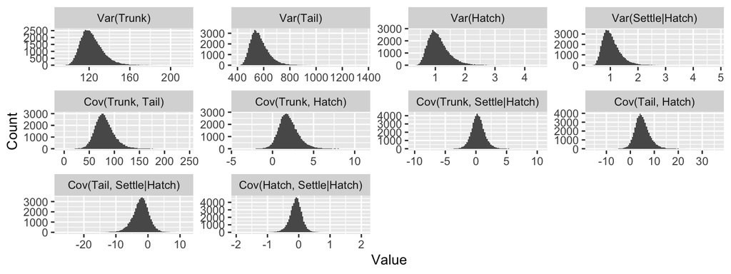

## V<sub>M</sub> / V<sub>A</sub>

Latent scale

| metric | lower.hdi | median | mode | upper.hdi | pr.lt.hdi | pr.gt.hdi | 5pc.exceeds | pct.gt.1 |
| --- | --- | --- | --- | --- | --- | --- | --- | --- |
| Var(Trunk) | -0.08515 | 1.833 | 1.179 | 12.51 | 0.00008 | 0.0499 | 12.49 | 0.7487 |
| Var(Tail) | -0.005524 | 1.476 | 1.029 | 6.194 | 0.0005 | 0.04948 | 6.157 | 0.6947 |
| Var(Hatch) | -0.2452 | 0.3234 | 0.1172 | 3.342 | 0 | 0.04998 | 3.339 | 0.2067 |
| Var(Settle\|Hatch) | -0.2489 | 0.1159 | -0.02116 | 2.095 | 0.00002 | 0.04996 | 2.095 | 0.1159 |
| Cov(Trunk, Tail) | -36.23 | 0.5109 | 0.457 | 39.83 | 0.02636 | 0.02362 | 18.84 | 0.4299 |
| Cov(Trunk, Hatch) | -10.31 | 0.4692 | 0.3285 | 12.73 | 0.02404 | 0.02594 | 6.755 | 0.32 |
| Cov(Trunk, Settle\|Hatch) | -12.39 | -0.2947 | -0.3095 | 12.37 | 0.02612 | 0.02386 | 5.542 | 0.1774 |
| Cov(Tail, Hatch) | -22.82 | 0.2978 | 0.1184 | 23.1 | 0.02486 | 0.02512 | 11.79 | 0.3519 |
| Cov(Tail, Settle\|Hatch) | -13.71 | -0.5177 | -0.5441 | 12 | 0.02392 | 0.02606 | 5.73 | 0.1742 |
| Cov(Hatch, Settle\|Hatch) | -10.59 | -0.3832 | -0.3096 | 10.65 | 0.02594 | 0.02404 | 4.629 | 0.1589 |

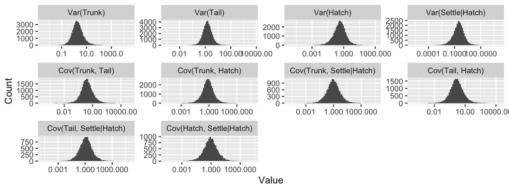

## V<sub>D</sub> / V<sub>A</sub>

Latent scale

| metric | lower.hdi | median | mode | upper.hdi | pr.lt.hdi | pr.gt.hdi | 5pc.exceeds | pct.gt.1 |
| --- | --- | --- | --- | --- | --- | --- | --- | --- |
| Var(Trunk) | 0.000006871 | 0.7008 | 0.3509 | 7.391 | 0 | 0.04998 | 7.383 | 0.385 |
| Var(Tail) | 0.0001596 | 0.653 | 0.3899 | 4.011 | 0 | 0.04998 | 4.009 | 0.3292 |
| Var(Hatch) | 0.0003365 | 1.059 | 0.6101 | 10 | 0 | 0.04998 | 9.998 | 0.5219 |
| Var(Settle\|Hatch) | 0.07596 | 1.381 | 0.8795 | 11.25 | 0.00006 | 0.04992 | 11.24 | 0.6425 |
| Cov(Trunk, Tail) | -16.75 | 0.02458 | 0.04912 | 15.11 | 0.02426 | 0.02572 | 7.484 | 0.239 |
| Cov(Trunk, Hatch) | -8.309 | -0.2126 | -0.2192 | 8.101 | 0.02516 | 0.02482 | 3.478 | 0.1162 |
| Cov(Trunk, Settle\|Hatch) | -14.89 | -0.04371 | -0.09066 | 15.65 | 0.02572 | 0.02426 | 7.339 | 0.2261 |
| Cov(Tail, Hatch) | -15.36 | -0.002677 | 0.0264 | 14.52 | 0.02506 | 0.02492 | 7.271 | 0.233 |
| Cov(Tail, Settle\|Hatch) | -12.07 | -0.2434 | -0.2222 | 11.06 | 0.02474 | 0.02524 | 5.354 | 0.1741 |
| Cov(Hatch, Settle\|Hatch) | -19.05 | 0.03139 | 0.02995 | 19.01 | 0.02532 | 0.02466 | 8.813 | 0.2639 |

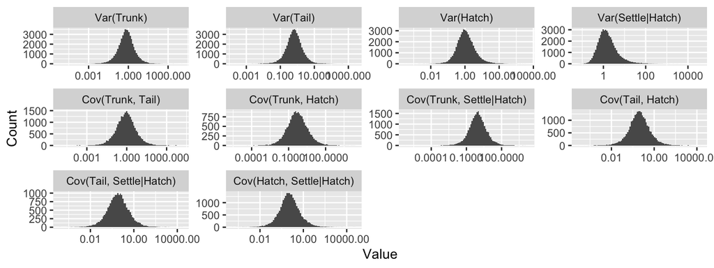

## Variance partitioning

Latent scale  
$(VA / VP) \times 100$

|  | Trunk | Tail |
| --- | --- | --- |
| **lower.hdi** | 0.001338 | 1.335 |
| **median** | 10.25 | 18.75 |
| **mode** | 7.897 | 16.02 |
| **upper.hdi** | 27.18 | 42.88 |
| **pr.lt.hdi** | 0 | 0.00602 |
| **pr.gt.hdi** | 0.04998 | 0.04396 |
| **5pc.exceeds** | 27.17 | 41.8 |

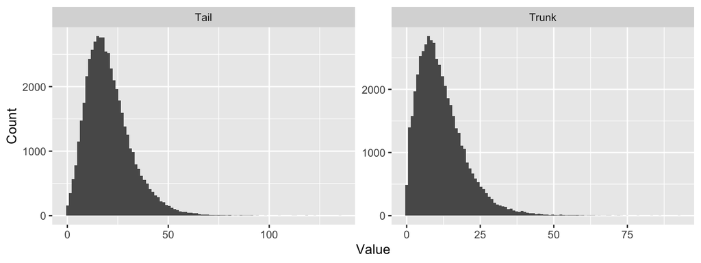

$(VM / VP) \times 100$

|  | Trunk | Tail |
| --- | --- | --- |
| **lower.hdi** | 6.306 | 11.58 |
| **median** | 18.17 | 27.03 |
| **mode** | 17.07 | 26.51 |
| **upper.hdi** | 32.83 | 45.21 |
| **pr.lt.hdi** | 0.01826 | 0.0238 |
| **pr.gt.hdi** | 0.03172 | 0.02618 |
| **5pc.exceeds** | 30.98 | 42.31 |

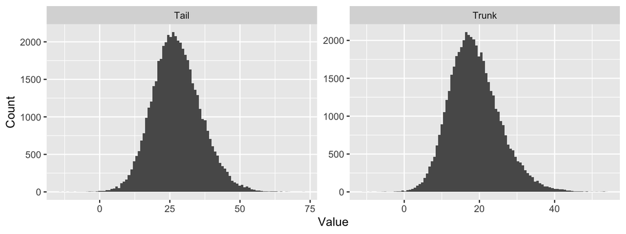

$(VD / VP) \times 100$

|  | Trunk | Tail |
| --- | --- | --- |
| **lower.hdi** | 0.00005468 | 0.04241 |
| **median** | 7.544 | 12.83 |
| **mode** | 4.395 | 10.8 |
| **upper.hdi** | 21.53 | 30.05 |
| **pr.lt.hdi** | 0 | 0.00026 |
| **pr.gt.hdi** | 0.04998 | 0.04972 |
| **5pc.exceeds** | 21.53 | 30.02 |

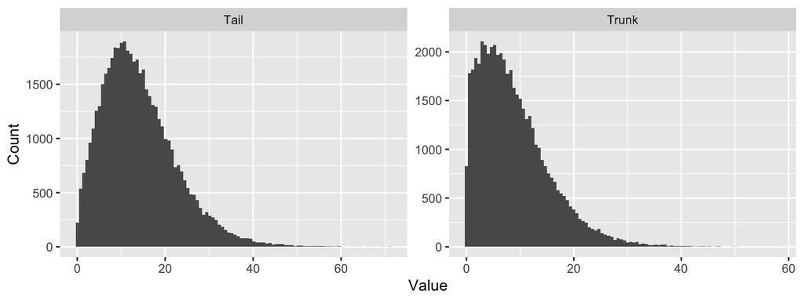

## Summarize QGmvparams posteriors

### Block means on expected data scale

Hatching actually measured in blocks 5, 7, 8, 9, 10, 11, 12, 13, 14, 16  
Settling actually measured in blocks 3, 4, 5, 7, 8, 9, 10, 11, 12, 14  
But **Block** has been re-coded for running model in runjags().

| Block | Stage | lower.hdi | median | mode | upper.hdi | pr.lt.hdi | pr.gt.hdi | 5pc.exceeds |
| --- | --- | --- | --- | --- | --- | --- | --- | --- |
| 3 | Hatch | NA | NA | NA | NA | NA | NA | NA |
| 4 | Hatch | NA | NA | NA | NA | NA | NA | NA |
| 5 | Hatch | 0.51 | 0.77 | 0.82 | 0.96 | 0.045 | 0.0051 | 0.93 |
| 7 | Hatch | 0.54 | 0.79 | 0.83 | 0.96 | 0.046 | 0.0037 | 0.93 |
| 8 | Hatch | 0.53 | 0.78 | 0.82 | 0.96 | 0.044 | 0.0055 | 0.93 |
| 9 | Hatch | 0.67 | 0.87 | 0.91 | 0.98 | 0.049 | 0.00056 | 0.96 |
| 10 | Hatch | 0.45 | 0.71 | 0.73 | 0.91 | 0.021 | 0.029 | 0.9 |
| 11 | Hatch | 0.47 | 0.72 | 0.75 | 0.92 | 0.026 | 0.024 | 0.9 |
| 12 | Hatch | 0.69 | 0.89 | 0.92 | 0.98 | 0.049 | 0.0006 | 0.96 |
| 13 | Hatch | 0.55 | 0.8 | 0.85 | 0.96 | 0.046 | 0.0042 | 0.93 |
| 14 | Hatch | 0.63 | 0.85 | 0.89 | 0.97 | 0.049 | 0.0012 | 0.95 |
| 16 | Hatch | 0.76 | 0.92 | 0.94 | 0.98 | 0.049 | 0.00072 | 0.97 |
| 3 | Settle\|Hatch | 0.5 | 0.81 | 0.88 | 0.97 | 0.049 | 0.00088 | 0.95 |
| 4 | Settle\|Hatch | 0.57 | 0.85 | 0.91 | 0.97 | 0.049 | 0.00064 | 0.96 |
| 5 | Settle\|Hatch | 0.41 | 0.74 | 0.82 | 0.96 | 0.047 | 0.0033 | 0.93 |
| 7 | Settle\|Hatch | 0.62 | 0.87 | 0.92 | 0.97 | 0.049 | 0.00064 | 0.96 |
| 8 | Settle\|Hatch | 0.45 | 0.76 | 0.83 | 0.97 | 0.047 | 0.0026 | 0.93 |
| 9 | Settle\|Hatch | 0.33 | 0.65 | 0.71 | 0.91 | 0.03 | 0.02 | 0.88 |
| 10 | Settle\|Hatch | 0.33 | 0.66 | 0.73 | 0.92 | 0.033 | 0.017 | 0.89 |
| 11 | Settle\|Hatch | 0.33 | 0.65 | 0.71 | 0.91 | 0.03 | 0.02 | 0.88 |
| 12 | Settle\|Hatch | 0.33 | 0.65 | 0.72 | 0.91 | 0.03 | 0.02 | 0.89 |
| 13 | Settle\|Hatch | NA | NA | NA | NA | NA | NA | NA |
| 14 | Settle\|Hatch | 0.54 | 0.82 | 0.89 | 0.97 | 0.049 | 0.001 | 0.95 |
| 16 | Settle\|Hatch | NA | NA | NA | NA | NA | NA | NA |

Summary across blocks

| Stage | min | max | mean_median | mean_mode |
| --- | --- | --- | --- | --- |
| Hatch | 0.71 | 0.92 | 0.81 | 0.85 |
| Settle\|Hatch | 0.65 | 0.87 | 0.75 | 0.81 |

### Block means on latent scale

| Block | Hatch | Settle\|Hatch |
| --- | --- | --- |
| 3 | NA | 1.7 |
| 4 | NA | 2.1 |
| 5 | 1.5 | 1.3 |
| 7 | 1.6 | 2.2 |
| 8 | 1.5 | 1.4 |
| 9 | 2.3 | 0.77 |
| 10 | 1.1 | 0.83 |
| 11 | 1.2 | 0.79 |
| 12 | 2.4 | 0.79 |
| 13 | 1.7 | NA |
| 14 | 2.1 | 1.8 |
| 16 | 2.8 | NA |

### VA for settling and hatching on data scale across blocks

| Block | Stage | lower.hdi | median | mode | upper.hdi | pr.lt.hdi | pr.gt.hdi | 5pc.exceeds | pct.gt.0 |
| --- | --- | --- | --- | --- | --- | --- | --- | --- | --- |
| 1 | Var(Hatch) | 0.00043 | 0.91 | 0.66 | 2.6 | 0 | 0.05 | 2.6 | 1 |
| 2 | Var(Hatch) | 0.00043 | 0.91 | 0.66 | 2.6 | 0 | 0.05 | 2.6 | 1 |
| 3 | Var(Hatch) | 0.00043 | 0.91 | 0.66 | 2.6 | 0 | 0.05 | 2.6 | 1 |
| 4 | Var(Hatch) | 0.00043 | 0.91 | 0.66 | 2.6 | 0 | 0.05 | 2.6 | 1 |
| 5 | Var(Hatch) | 0.0000019 | 0.017 | 0.0086 | 0.069 | 0 | 0.05 | 0.069 | 1 |
| 7 | Var(Hatch) | 0.000006 | 0.016 | 0.008 | 0.066 | 0.00002 | 0.05 | 0.066 | 1 |
| 8 | Var(Hatch) | 0.0000042 | 0.017 | 0.0085 | 0.068 | 0 | 0.05 | 0.068 | 1 |
| 9 | Var(Hatch) | 0.0000007 | 0.0076 | 0.0038 | 0.046 | 0 | 0.05 | 0.046 | 1 |
| 10 | Var(Hatch) | 0.000005 | 0.023 | 0.012 | 0.076 | 0 | 0.05 | 0.076 | 1 |
| 11 | Var(Hatch) | 0.0000091 | 0.022 | 0.012 | 0.075 | 0 | 0.05 | 0.075 | 1 |
| 12 | Var(Hatch) | 0.0000013 | 0.0066 | 0.0033 | 0.041 | 0 | 0.05 | 0.041 | 1 |
| 13 | Var(Hatch) | 0.0000024 | 0.015 | 0.0075 | 0.064 | 0 | 0.05 | 0.064 | 1 |
| 14 | Var(Hatch) | 0.0000011 | 0.0098 | 0.0049 | 0.052 | 0 | 0.05 | 0.052 | 1 |
| 15 | Var(Hatch) | 0.00043 | 0.91 | 0.66 | 2.6 | 0 | 0.05 | 2.6 | 1 |
| 16 | Var(Hatch) | 0.0000013 | 0.0038 | 0.0019 | 0.03 | 0 | 0.05 | 0.03 | 1 |
| 1 | Var(Settle\|Hatch) | 0.000037 | 0.96 | 0.73 | 2.8 | 0 | 0.05 | 2.8 | 1 |
| 2 | Var(Settle\|Hatch) | 0.000037 | 0.96 | 0.73 | 2.8 | 0 | 0.05 | 2.8 | 1 |
| 3 | Var(Settle\|Hatch) | 0.0000001 | 0.014 | 0.007 | 0.068 | 0 | 0.05 | 0.068 | 1 |
| 4 | Var(Settle\|Hatch) | 0.000000048 | 0.01 | 0.0051 | 0.062 | 0 | 0.05 | 0.062 | 1 |
| 5 | Var(Settle\|Hatch) | 0.00000035 | 0.021 | 0.011 | 0.08 | 0 | 0.05 | 0.08 | 1 |
| 7 | Var(Settle\|Hatch) | 0.00000014 | 0.009 | 0.0045 | 0.056 | 0 | 0.05 | 0.056 | 1 |
| 8 | Var(Settle\|Hatch) | 0.00000022 | 0.019 | 0.0096 | 0.077 | 0 | 0.05 | 0.077 | 1 |
| 9 | Var(Settle\|Hatch) | 0.0000005 | 0.028 | 0.016 | 0.089 | 0 | 0.05 | 0.089 | 1 |
| 10 | Var(Settle\|Hatch) | 0.0000004 | 0.027 | 0.015 | 0.087 | 0 | 0.05 | 0.087 | 1 |
| 11 | Var(Settle\|Hatch) | 0.00000067 | 0.028 | 0.015 | 0.087 | 0 | 0.05 | 0.087 | 1 |
| 12 | Var(Settle\|Hatch) | 0.00000045 | 0.028 | 0.015 | 0.088 | 0 | 0.05 | 0.088 | 1 |
| 13 | Var(Settle\|Hatch) | 0.000037 | 0.96 | 0.73 | 2.8 | 0 | 0.05 | 2.8 | 1 |
| 14 | Var(Settle\|Hatch) | 0.00000019 | 0.013 | 0.0067 | 0.067 | 0 | 0.05 | 0.067 | 1 |
| 15 | Var(Settle\|Hatch) | 0.000037 | 0.96 | 0.73 | 2.8 | 0 | 0.05 | 2.8 | 1 |
| 16 | Var(Settle\|Hatch) | 0.000037 | 0.96 | 0.73 | 2.8 | 0 | 0.05 | 2.8 | 1 |

[output cut: 75 more lines]

### VP for settling and hatching on data scale across blocks

| Block | Stage | lower.hdi | median | mode | upper.hdi | pr.lt.hdi | pr.gt.hdi | 5pc.exceeds | pct.gt.0 |
| --- | --- | --- | --- | --- | --- | --- | --- | --- | --- |
| 1 | Var(Hatch) | 0.51 | 1.1 | 0.98 | 1.8 | 0.008 | 0.042 | 1.8 | 1 |
| 2 | Var(Hatch) | 0.51 | 1.1 | 0.98 | 1.8 | 0.008 | 0.042 | 1.8 | 1 |
| 3 | Var(Hatch) | 0.51 | 1.1 | 0.98 | 1.8 | 0.008 | 0.042 | 1.8 | 1 |
| 4 | Var(Hatch) | 0.51 | 1.1 | 0.98 | 1.8 | 0.008 | 0.042 | 1.8 | 1 |
| 5 | Var(Hatch) | 0.064 | 0.18 | 0.21 | 0.25 | 0.05 | 0.00008 | 0.25 | 1 |
| 7 | Var(Hatch) | 0.066 | 0.17 | 0.21 | 0.25 | 0.05 | 0.00006 | 0.25 | 1 |
| 8 | Var(Hatch) | 0.068 | 0.17 | 0.21 | 0.25 | 0.05 | 0.00004 | 0.25 | 1 |
| 9 | Var(Hatch) | 0.028 | 0.11 | 0.084 | 0.22 | 0.005 | 0.045 | 0.22 | 1 |
| 10 | Var(Hatch) | 0.093 | 0.21 | 0.23 | 0.25 | 0.05 | 0.00014 | 0.25 | 1 |
| 11 | Var(Hatch) | 0.091 | 0.2 | 0.23 | 0.25 | 0.05 | 0.00002 | 0.25 | 1 |
| 12 | Var(Hatch) | 0.025 | 0.1 | 0.071 | 0.21 | 0.0019 | 0.048 | 0.21 | 1 |
| 13 | Var(Hatch) | 0.062 | 0.16 | 0.21 | 0.25 | 0.049 | 0.0007 | 0.25 | 1 |
| 14 | Var(Hatch) | 0.034 | 0.13 | 0.11 | 0.24 | 0.014 | 0.036 | 0.23 | 1 |
| 15 | Var(Hatch) | 0.51 | 1.1 | 0.98 | 1.8 | 0.008 | 0.042 | 1.8 | 1 |
| 16 | Var(Hatch) | 0.023 | 0.074 | 0.052 | 0.18 | 0.001 | 0.049 | 0.18 | 1 |
| 1 | Var(Settle\|Hatch) | 0.52 | 0.99 | 0.9 | 1.7 | 0.0079 | 0.042 | 1.7 | 1 |
| 2 | Var(Settle\|Hatch) | 0.52 | 0.99 | 0.9 | 1.7 | 0.0079 | 0.042 | 1.7 | 1 |
| 3 | Var(Settle\|Hatch) | 0.046 | 0.15 | 0.2 | 0.25 | 0.049 | 0.0007 | 0.25 | 1 |
| 4 | Var(Settle\|Hatch) | 0.038 | 0.12 | 0.083 | 0.25 | 0.05 | 0.00036 | 0.24 | 1 |
| 5 | Var(Settle\|Hatch) | 0.065 | 0.19 | 0.22 | 0.25 | 0.05 | 0.00004 | 0.25 | 1 |
| 7 | Var(Settle\|Hatch) | 0.028 | 0.12 | 0.076 | 0.24 | 0.0044 | 0.046 | 0.23 | 1 |
| 8 | Var(Settle\|Hatch) | 0.063 | 0.18 | 0.22 | 0.25 | 0.05 | 0.0001 | 0.25 | 1 |
| 9 | Var(Settle\|Hatch) | 0.1 | 0.22 | 0.24 | 0.25 | 0.05 | 0.00006 | 0.25 | 1 |
| 10 | Var(Settle\|Hatch) | 0.095 | 0.22 | 0.24 | 0.25 | 0.05 | 0.00002 | 0.25 | 1 |
| 11 | Var(Settle\|Hatch) | 0.1 | 0.22 | 0.24 | 0.25 | 0.05 | 0.00014 | 0.25 | 1 |
| 12 | Var(Settle\|Hatch) | 0.1 | 0.22 | 0.24 | 0.25 | 0.05 | 0.00002 | 0.25 | 1 |
| 13 | Var(Settle\|Hatch) | 0.52 | 0.99 | 0.9 | 1.7 | 0.0079 | 0.042 | 1.7 | 1 |
| 14 | Var(Settle\|Hatch) | 0.047 | 0.15 | 0.2 | 0.25 | 0.05 | 0.00024 | 0.25 | 1 |
| 15 | Var(Settle\|Hatch) | 0.52 | 0.99 | 0.9 | 1.7 | 0.0079 | 0.042 | 1.7 | 1 |
| 16 | Var(Settle\|Hatch) | 0.52 | 0.99 | 0.9 | 1.7 | 0.0079 | 0.042 | 1.7 | 1 |

[output cut: 75 more lines]

$\boldsymbol{\beta}_{g} = \mathbf{G}^{-1}\mathbf{s}_{g}$

## Evolvability (for single traits)

|  | Trunk | Tail |
| --- | --- | --- |
| **lower.hdi** | 0.00000004301 | 0.000004748 |
| **median** | 0.0002986 | 0.0005173 |
| **mode** | 0.000231 | 0.0004512 |
| **upper.hdi** | 0.0008165 | 0.001197 |
| **pr.lt.hdi** | 0 | 0.00052 |
| **pr.gt.hdi** | 0.04998 | 0.04946 |
| **5pc.exceeds** | 0.0008164 | 0.001194 |

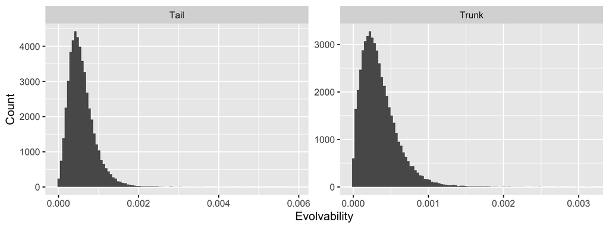

Evolvability as a percentage

|  | Trunk | Tail |
| --- | --- | --- |
| **lower.hdi** | 0.000004301 | 0.0004748 |
| **median** | 0.02986 | 0.05173 |
| **mode** | 0.0231 | 0.04512 |
| **upper.hdi** | 0.08165 | 0.1197 |
| **pr.lt.hdi** | 0 | 0.00052 |
| **pr.gt.hdi** | 0.04998 | 0.04946 |
| **5pc.exceeds** | 0.08164 | 0.1194 |

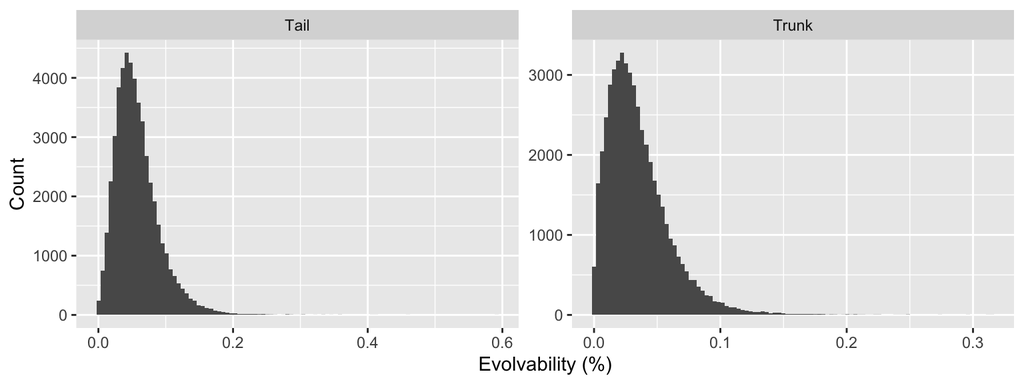

## Tail / Trunk Evolvability

| lower.hdi | median | mode | upper.hdi | pr.lt.hdi | pr.gt.hdi | 5pc.exceeds |
| --- | --- | --- | --- | --- | --- | --- |
| 0.2189 | 1.734 | 1.552 | 17.44 | 1.021 | 1.03 | 11.44 |

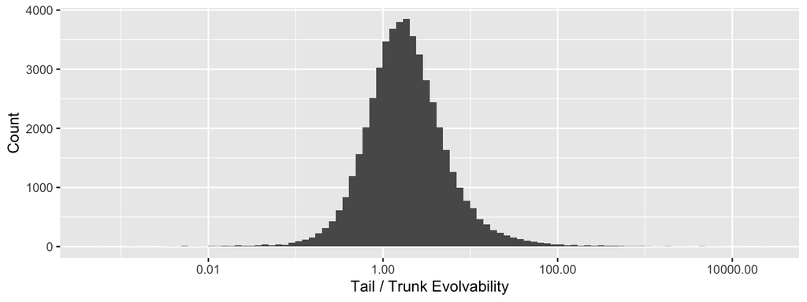

## Evolvability (from G matrix) Approach 1

This is for a random set of selection gradients.  
Multiply eB by 100 to get in units of percent.

| name | lower.hdi | median | mode | upper.hdi | pr.lt.hdi | pr.gt.hdi | 5pc.exceeds |
| --- | --- | --- | --- | --- | --- | --- | --- |
| eB | 0.00004 | 0.000249 | 0.000223 | 0.000559 | 0.00664 | 0.04334 | 0.000542 |
| rB | 0.000033 | 0.00029 | 0.00025 | 0.000663 | 0.0032 | 0.04678 | 0.000652 |
| cB | 0.000017 | 0.000135 | 0.00012 | 0.000286 | 0.00744 | 0.04254 | 0.000278 |
| iB | 0.0255 | 0.4308 | 0.4379 | 0.7903 | 0.0102 | 0.03978 | 0.7697 |
| aB | 0.2097 | 0.5692 | 0.5621 | 0.9745 | 0.03978 | 0.0102 | 0.9037 |

## Evolvability (from G matrix) Approach 2

This is for a specific set of selection gradients:  
Beta_index = 1 is $\beta = \begin{bmatrix} 0 \\ 1 \end{bmatrix}$ = strong selection for longer tails only  
Beta_index = 2 is $\beta = \begin{bmatrix} -(1/\sqrt2) \\ -(1/\sqrt2) \end{bmatrix}$ = strong selection for shorter trunks and shorter tails  
Beta_index = 3 is $\beta = \begin{bmatrix} (1/\sqrt2) \\ -(1/\sqrt2) \end{bmatrix}$ = strong selection for longer trunks and shorter tails  
Multiply ‘evolvability’ by 100 to get in units of percent.

| Beta_index | metric | lower.hdi | median | mode | upper.hdi | pr.lt.hdi | pr.gt.hdi | 5pc.exceeds |
| --- | --- | --- | --- | --- | --- | --- | --- | --- |
| 1 | evolvability | 0.000005 | 0.000517 | 0.000451 | 0.001197 | 0.00052 | 0.04946 | 0.001194 |
| 2 | evolvability | 0.000046 | 0.000449 | 0.000386 | 0.001077 | 0.00294 | 0.04704 | 0.001062 |
| 3 | evolvability | 0.000059 | 0.000377 | 0.000322 | 0.000875 | 0.00476 | 0.04522 | 0.000856 |
| 1 | respondability | 0.000047 | 0.000536 | 0.000461 | 0.001256 | 0.00504 | 0.04494 | 0.001224 |
| 2 | respondability | 0.000057 | 0.000491 | 0.000424 | 0.001146 | 0.0028 | 0.04718 | 0.00113 |
| 3 | respondability | 0.00008 | 0.000424 | 0.000361 | 0.000972 | 0.00664 | 0.04334 | 0.000943 |
| 1 | conditional | 0.000001 | 0.000446 | 0.000377 | 0.00106 | 0.00022 | 0.04976 | 0.001059 |
| 2 | conditional | 0 | 0.000339 | 0.000283 | 0.000895 | 0 | 0.04998 | 0.000895 |
| 3 | conditional | 0 | 0.000284 | 0.000236 | 0.000716 | 0.00006 | 0.04992 | 0.000716 |
| 1 | autonomy (cB/eB) | 0.5303 | 0.9303 | 0.9651 | 1 | 0.04998 | 0 | 0.9993 |
| 2 | autonomy (cB/eB) | 0.2301 | 0.8557 | 0.9278 | 1 | 0.04998 | 0 | 0.9986 |
| 3 | autonomy (cB/eB) | 0.2301 | 0.8557 | 0.9278 | 1 | 0.04998 | 0 | 0.9986 |
| 1 | integration | 0 | 0.06973 | 0.03486 | 0.4697 | 0 | 0.04998 | 0.4697 |
| 2 | integration | 0 | 0.1443 | 0.07216 | 0.7699 | 0 | 0.04998 | 0.7698 |
| 3 | integration | 0 | 0.1443 | 0.07216 | 0.7699 | 0 | 0.04998 | 0.7698 |

## Response to selection (%) from covariance. Approach 3

| param | lower.hdi | median | mode | upper.hdi | pr.lt.hdi | pr.gt.hdi | 5pc.exceeds |
| --- | --- | --- | --- | --- | --- | --- | --- |
| Tail : Settle\|Hatch | -0.3794 | 0.04243 | 0.03524 | 0.6261 | 0.023 | 0.027 | 0.4856 |
| Trunk : Settle\|Hatch | -0.5198 | -0.01318 | -0.0147 | 0.4164 | 0.0258 | 0.0242 | 0.2862 |
| Tail : Hatch | -0.2953 | 0.0222 | 0.01756 | 0.437 | 0.02294 | 0.02706 | 0.3359 |
| Trunk : Hatch | -0.09038 | 0.1071 | 0.06529 | 0.6009 | 0.01149 | 0.03851 | 0.5458 |

## Total response to selection (%) from covariance

| param | lower.hdi | median | mode | upper.hdi | pr.lt.hdi | pr.gt.hdi | 5pc.exceeds |
| --- | --- | --- | --- | --- | --- | --- | --- |
| Tail | -0.4951 | 0.08934 | 0.07053 | 0.8341 | 0.0219 | 0.0281 | 0.6783 |
| Trunk | -0.468 | 0.1071 | 0.08751 | 0.8433 | 0.02204 | 0.02796 | 0.6875 |